# Bootstrap

Cyrus Samii

2/26/2019

## Inverse Propensity Score Weighting (IPW)

Recall that the stabilized IPW estimator for the ATE is
$$\hat{\rho}_{IPW} = \frac{\sum_{i=1}^n \frac{D_i}{\hat{e}(X_i)}Y_i}{\sum_{i=1}^n \frac{D_i}{\hat{e}(X_i)}} - \frac{\sum_{i=1}^n \frac{1-D_i}{1-\hat{e}(X_i)}Y_i}{\sum_{i=1}^n \frac{1-D_i}{1-\hat{e}(X_i)}},$$
and that this can be implementing with weighted least squares regression in which you regress $Y$ on $D$, using the inverse of the estimate propensity score $\hat{e}(X_i)$ as the weights for the treated and the inverse of $1-\hat{e}(X_i)$ as the weights for the control.

Inference for $\hat{\rho}_{IPW}$ should account for the sampling variation in the estimated propensity scores, $\hat{e}(\cdot)$. In the Robust Inference I lecture notes, we showed how to derived the variance when $\hat{e}(\cdot)$ is estimated using an $M$-estimator. Here we will use the bootstrap instead.

### Make a simulated population with confounding

We will simulate a population with confounding in $X$. We do it in a way that makes it so that simple control specifications for $X$ in a regression would be inadequate, and so the specification challenge is a little harder than usual:

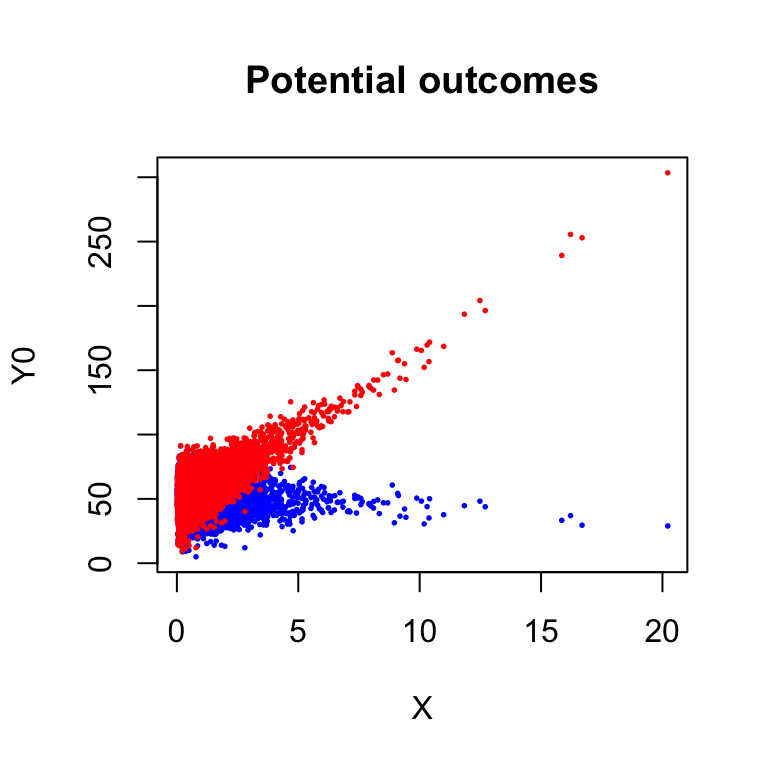

```r
# Make population data
set.seed(11)
N.pop <- 10000
index <- 1:N.pop
X <- .5*exp(rnorm(N.pop))
Y0 <- 50-.05*X^2+(1+.5*(max(X)-X))*rnorm(N.pop)
Y1 <- -1.5 + Y0 + 10*X + .2*X^2+ .25*X*rnorm(N.pop)
e.X <- (1+exp(1-.2*X))^(-1)
D <- rbinom(N.pop, 1, e.X)
Y <- D*Y1 + (1-D)*Y0
rho <- mean(Y1-Y0)

plot(X, Y0, col="blue", pch=19,
     cex=.25, ylim=range(c(Y1,Y0)),
     main="Potential outcomes")
points(X, Y1, col="red", pch=19, cex=.25)
```

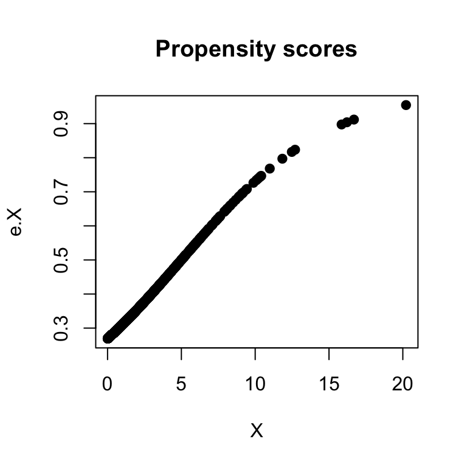

```r
plot(X, e.X, pch=19, main="Propensity scores")
```

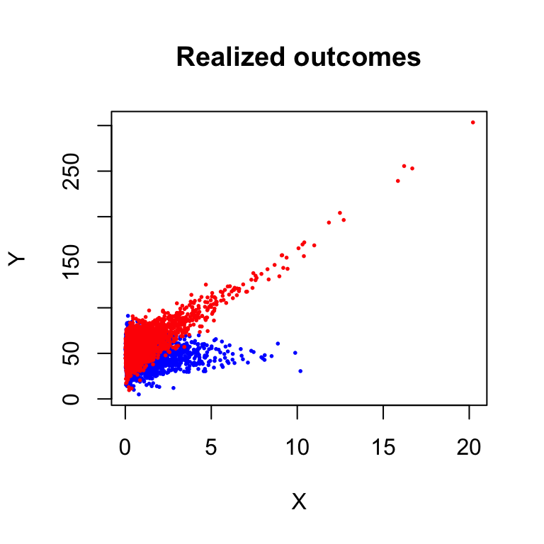

```r
plot(X, Y, type="n", ,
     main="Realized outcomes")
points(X[D==0], Y[D==0], col="blue", pch=19, cex=.25)
points(X[D==1], Y[D==1], col="red", pch=19, cex=.25)
```

```r
rho
```

```
## [1] 7.124273
```

```r
summary(lm(Y~D))[[4]][,1]
```

```
## (Intercept)           D
##   49.800748    9.237881
```

```r
summary(lm(Y~D+X))[[4]][,1]
```

```
## (Intercept)           D           X
##   45.379997    7.790128    5.881640
```

```r
summary(lm(Y~D*I(X-mean(X))))[[4]][,1]
```

```
##      (Intercept)                D   I(X - mean(X)) D:I(X - mean(X))
##       49.7601797        7.3606239       -0.5394921       11.7581545
```

```r
pop.data <- data.frame(index, Y, D, X)
```

### Sampling process

Next we draw a sample and estimate the effect using simple regression strategies and then IPW:

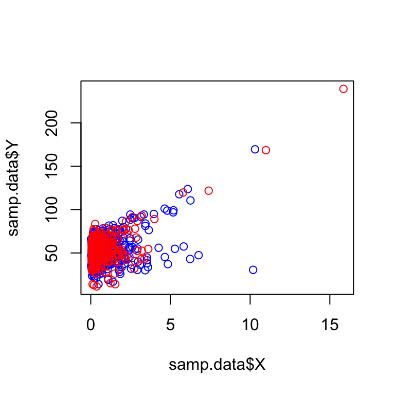

```r
# Draw a sample:
n.samp <- 1000

samp.i <- sample(index, n.samp)
samp.data <- pop.data[samp.i,]
plot(samp.data$X, samp.data$Y, type="n")
points(samp.data$X[D==0], samp.data$Y[D==0], col="blue")
points(samp.data$X[D==1], samp.data$Y[D==1], col="red")
```

```r
summary(lm(Y~D, data=samp.data))[[4]][,1]
```

```
## (Intercept)           D
##    49.18994    10.72004
```

```r
summary(lm(Y~D+X, data=samp.data))[[4]][,1]
```

```
## (Intercept)           D           X
##   44.331840    8.891598    6.449878
```

```r
summary(lm(Y~D*I(X-mean(X)), data=samp.data))[[4]][,1]
```

```
##      (Intercept)                D   I(X - mean(X)) D:I(X - mean(X))
##       49.1173279        8.5252179       -0.8426236       12.3346502
```

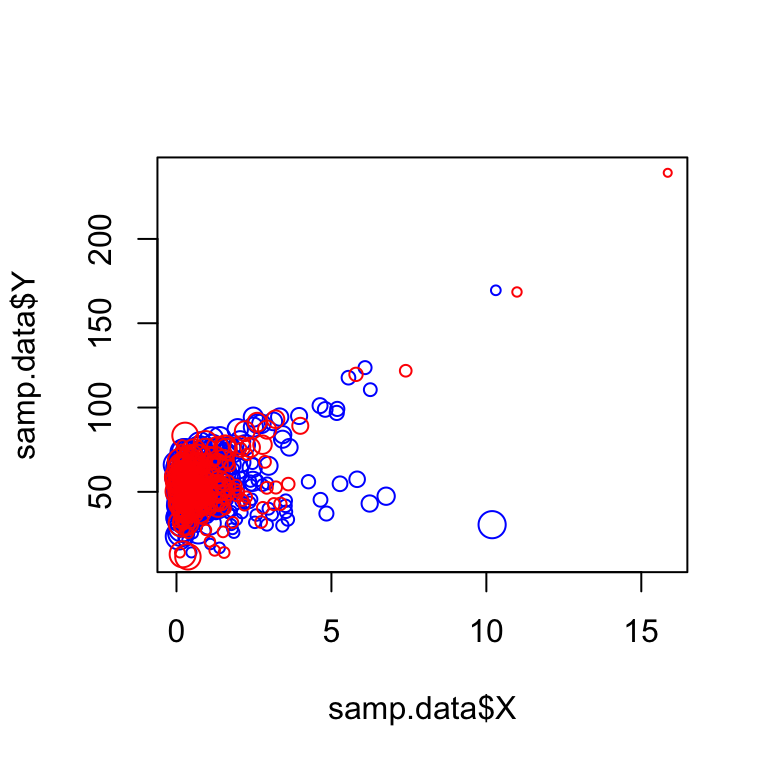

```r
e.hat.X <- predict(glm(D~X, data=samp.data,
                        family="binomial"),
                        type="response")

samp.data$w <- samp.data$D*(1/e.hat.X) + (1-samp.data$D)*(1/(1-e.hat.X))

plot(samp.data$X, samp.data$Y, type="n")
points(samp.data$X[D==0], samp.data$Y[D==0],
       cex=.5*samp.data$w[D==0],col="blue")
points(samp.data$X[D==1], samp.data$Y[D==1],
       cex=.5*samp.data$w[D==1],col="red")
```

### Fitting IPW model

```r
fit.ipsw.s <- lm(Y~D, weights=samp.data$w, data=samp.data)
summary(fit.ipsw.s)[[5]][,1]
```

```
## (Intercept)           D
##   49.114690    8.478966
```

### Estimating the standard error

```r
# Get bootstrap estimate
n.boot <- 500
ate.hat <- rep(NA, n.boot)
t.out <- rep(NA, n.boot)

for (i in 1:n.boot){
    boot.index <- sample(samp.data$index, n.samp, replace=T)
    boot.data <- samp.data[match(boot.index, samp.data$index),]
    e.hat.boot <- predict(glm(D~X, data=boot.data,
                            family="binomial"),
                            type="response")
boot.data$w <- boot.data$D*(1/e.hat.boot)/sum(boot.data$D*(1/e.hat.boot)) + (1-boot.data$D)*(1/(1-e.hat.boot))/sum((1-boot.data$D)*(1/(1-e.hat.boot)))
    fit.ipsw.b <- lm(Y~D, weights=boot.data$w, data=boot.data)
    ate.hat[i] <- coef(fit.ipsw.b)[2]
    t.out[i] <- coeftest(fit.ipsw.b , vcov.= vcovHC(fit.ipsw.b, "HC2"))[2,3]
    cat(paste(i, " ")); flush.console() # progress indicator
}
```

[output not shown]

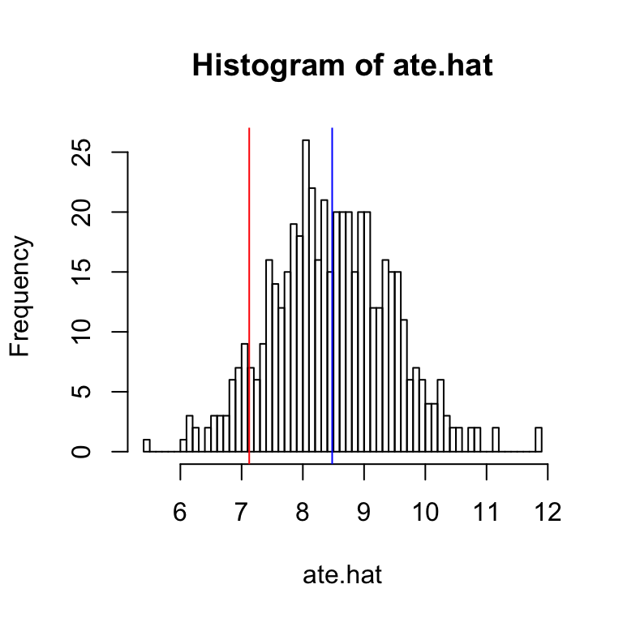

```r
hist(ate.hat, breaks=50)
abline(v=coef(fit.ipsw.s)[2], col="blue")
abline(v=rho, col="red")
```

```r
aCI.out <- coeftest(fit.ipsw.s , vcov.= vcovHC(fit.ipsw.s, "HC2"))

# Naive analytical asymptotic CI ignoring pscore estimation
aaCI <- c(aCI.out[2,1]-qt(.975, fit.ipsw.s[[9]])*aCI.out[2,2], aCI.out[2,1]+qt(.975, fit.ipsw.s[[9]])*aCI.out[2,2])
# Bootstrap-b CI
bbCI <- quantile(ate.hat, c(0.025, .975))
# Bootstrap-t CI
btCI <- aCI.out[2,2]*quantile(t.out, c(0.025, .975))

coef(fit.ipsw.s)[2]
```

```
##        D
## 8.478966
```

```r
aaCI
```

```
## [1]  6.520593 10.437340
```

```r
bbCI
```

```
##      2.5%     97.5%
##  6.614625 10.355653
```

```r
btCI
```

```
##      2.5%     97.5%
##  6.580765 10.348629
```

### Comparing to the true sampling distribution

```r
n.iter <- 500
ate.hat.s <- rep(NA, n.iter)
t.out.s <- rep(NA, n.iter)

for(j in 1:n.iter){
    samp.i <- sample(index, n.samp)
    samp.data <- pop.data[samp.i,]
    e.hat.X <- predict(glm(D~X, data=samp.data,
                        family="binomial"),
                        type="response")
    samp.data$w <- samp.data$D*(1/e.hat.X) + (1-samp.data$D)*(1/(1-e.hat.X))
    fit.ipsw <- lm(Y~D, weights=samp.data$w, data=samp.data)
    ate.hat.s[j] <- coef(fit.ipsw)[2]
    t.out.s[j] <- coeftest(fit.ipsw , vcov.= vcovHC(fit.ipsw, "HC2"))[2,3]
    cat(paste(j, " ")); flush.console() # progress indicator
}
```

[output not shown]

```r
# True coef mean
mean(ate.hat.s)
```

```
## [1] 7.405926
```

```r
# Estimate
coef(fit.ipsw.s)[2]
```

```
##        D
## 8.478966
```

```r
# True sampling sd
sd(ate.hat.s)
```

```
## [1] 0.7989762
```

```r
# Estimates
#  Naive analytical
aCI.out[2,2]
```

```
## [1] 0.9979767
```

```r
#  bootstrap-b
sd(ate.hat)
```

```
## [1] 0.9788662
```

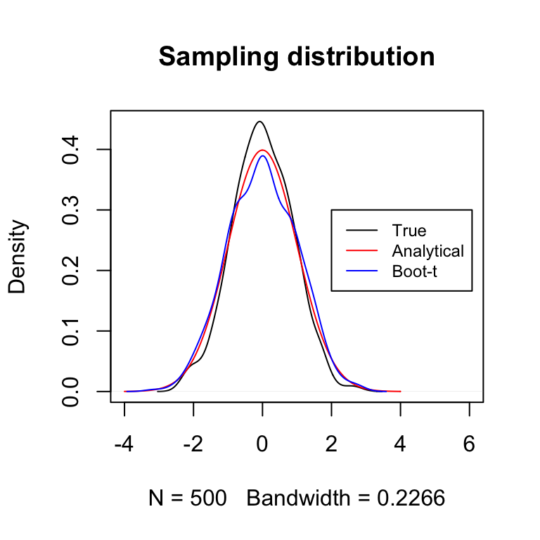

```r
# True t stat dist
plot(density(t.out.s-mean(t.out.s)),
     main="Sampling distribution",
     xlim=c(-4,6))
# Estimates:
#   Analytical
points( seq(-4,4,.01),
        dt(seq(-4,4,.01),
        df=fit.ipsw.s[[9]]),
        type="l",
        col="red")
#  Bootstrap-t
points(density(t.out-mean(t.out)), type="l",col="blue")
legend(2,.3, legend=c("True","Analytical","Boot-t"),
       col=c("black","red","blue"),
       lty=c("solid","solid","solid"),
       cex=.75)
```

## Bootstrap failure

We will show the failure of the bootstrap for estimates of the maximum, using $\max\{X_i\}$ for units $i$ in the sample. This is a non-smooth statistic:

First, we can view our target, the population maximum, relative to what we get in our sample:

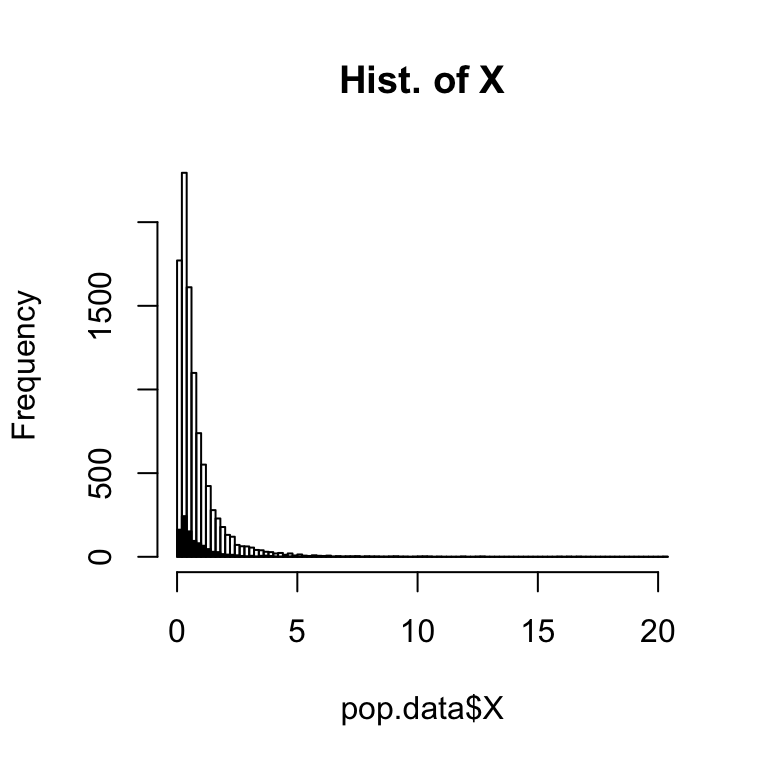

```r
par(mfrow=c(1,1))
pophist <- hist(pop.data$X, breaks=100, freq=TRUE, main="Hist. of X")
hist(samp.data$X, add=TRUE, breaks=pophist$breaks, col="black")
```

```r
max(pop.data$X)
```

```
## [1] 20.21729
```

```r
max(samp.data$X)
```

```
## [1] 12.70117
```

Now look at the sampling distribution of $\max\{X_i\}$:

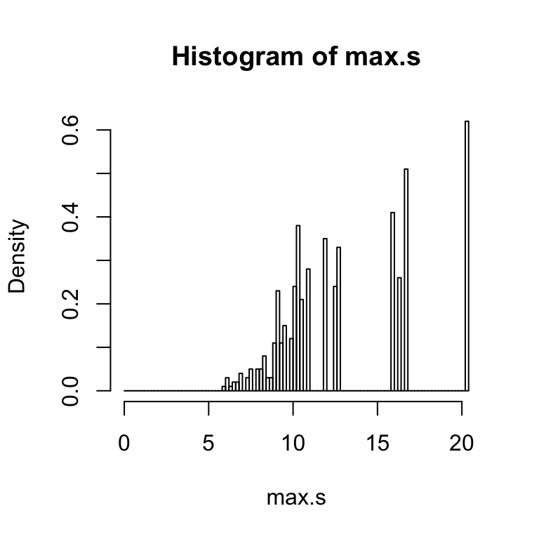

```r
max.s <- rep(NA, n.iter)

for(j in 1:n.iter){
    samp.i <- sample(index, n.samp)
    samp.data <- pop.data[samp.i,]
    max.s[j] <-  max(samp.data$X)
}

hist(max.s, freq=F, breaks=pophist$breaks)
```

Now look at how the bootstrap attempts to approximate this:

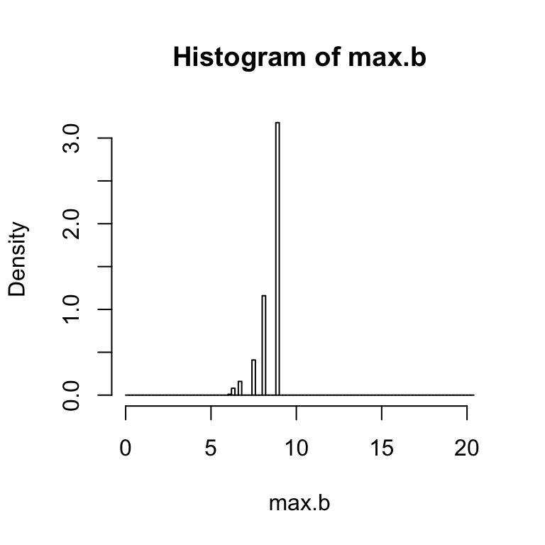

```r
max.b <- rep(NA, n.iter)

for (i in 1:n.boot){
    boot.index <- sample(samp.data$index, n.samp, replace=T)
    boot.data <- samp.data[match(boot.index, samp.data$index),]
    max.b[i] <-  max(boot.data$X)
}

hist(max.b, freq=F, breaks=pophist$breaks)
```

```r
sd(max.s)
```

```
## [1] 3.907458
```

```r
sd(max.b)
```

```
## [1] 0.6836264
```